# Affect-AAT model with 2 blocks only

Kristina Kobrock

14 3 2022

# The role of affect in the Automatic Approach Bias: An empirical investigation.

## The effect of mood induction in the AAB

### How long does a mood induction hold?

### Analysis with two instead of four blocks per session

I’m conducting the same preprocessing steps as in the main analysis.

The two last blocks are excluded.

After having excluded the practice trials, this still leaves us with 15.200 observations.

After having excluded all incorrect trials and trials with unreasonably short or large reaction times, I’m left with 14.444 observations. Reaction times range between 155.58ms and 2861.68 (mean=922.52, sd=349.6) which is comparable to the main analysis.

```
##   subject_id trial condition mood_induction  log_RT_s pictures stimulus_valence
## 1          1     5 congruent       positive 1.2343842       72         negative
## 2          1     6 congruent       positive 0.4734490       62         negative
## 3          1     7 congruent       positive 2.1109738       46         negative
## 4          1     8 congruent       positive 0.4720166       84         negative
## 5          1     9 congruent       positive 0.8210851       17         positive
## 6          1    10 congruent       positive 1.7624680       30         positive
##   response
## 1     push
## 2     push
## 3     push
## 4     push
## 5     pull
## 6     pull
```

Log-transformed normal model with same specifications as before (same priors and group-level effects for subject_id) for 4000 iterations:

Notably, the two block model converges more easily when including group-level effects for subject_id:

```r
summary(fit_2block, priors=TRUE)
```

```
##  Family: gaussian
##   Links: mu = identity; sigma = identity
## Formula: log_RT_s ~ condition * mood_induction + (condition * mood_induction || subject_id)
##    Data: df_aat_log1 (Number of observations: 14444)
##   Draws: 4 chains, each with iter = 4000; warmup = 2000; thin = 1;
##          total post-warmup draws = 8000
##
## Priors:
## b ~ normal(0, 10)
## Intercept ~ student_t(3, 0, 3)
## sd ~ student_t(3, 0, 2.5)
## sigma ~ student_t(3, 0, 3)
##
## Group-Level Effects:
## ~subject_id (Number of levels: 95)
##                                                 Estimate Est.Error l-95% CI
## sd(Intercept)                                       0.67      0.05     0.58
## sd(conditionincongruent)                            0.33      0.03     0.27
## sd(mood_inductionpositive)                          0.59      0.05     0.51
## sd(conditionincongruent:mood_inductionpositive)     0.38      0.04     0.31
##                                                 u-95% CI Rhat Bulk_ESS Tail_ESS
## sd(Intercept)                                       0.77 1.00     4035     4451
## sd(conditionincongruent)                            0.39 1.00     4551     6404
## sd(mood_inductionpositive)                          0.69 1.00     3776     5438
## sd(conditionincongruent:mood_inductionpositive)     0.46 1.00     4907     6697
##
## Population-Level Effects:
##                                             Estimate Est.Error l-95% CI
## Intercept                                      -0.02      0.07    -0.15
## conditionincongruent                            0.12      0.04     0.04
## mood_inductionpositive                         -0.02      0.06    -0.14
## conditionincongruent:mood_inductionpositive    -0.04      0.05    -0.14
##                                             u-95% CI Rhat Bulk_ESS Tail_ESS
## Intercept                                       0.12 1.00     3921     3849
## conditionincongruent                            0.19 1.00     7337     5057
## mood_inductionpositive                          0.10 1.00     4748     4623
## conditionincongruent:mood_inductionpositive     0.04 1.00     8570     5722
##
## Family Specific Parameters:
##       Estimate Est.Error l-95% CI u-95% CI Rhat Bulk_ESS Tail_ESS
## sigma     0.73      0.00     0.72     0.74 1.00     8857     4873
##
## Draws were sampled using sampling(NUTS). For each parameter, Bulk_ESS
## and Tail_ESS are effective sample size measures, and Rhat is the potential
## scale reduction factor on split chains (at convergence, Rhat = 1).
```

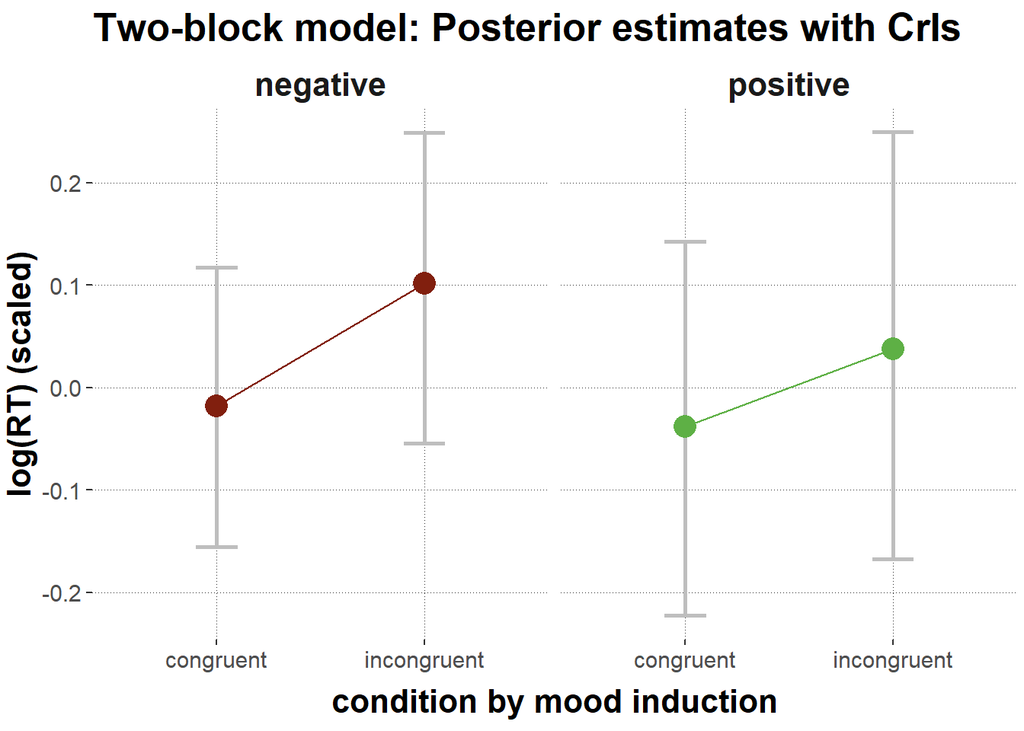

Compared to the main analysis, here the rather flat slope indicating the AAB after positive mood induction attracts attention. In light of the two hypotheses from the preregistration, this result would be at least as suprising as the result from the main analysis: Not in the negative mood induction condition as predicted but in the positive mood induction condition, is the AAB leveled out!

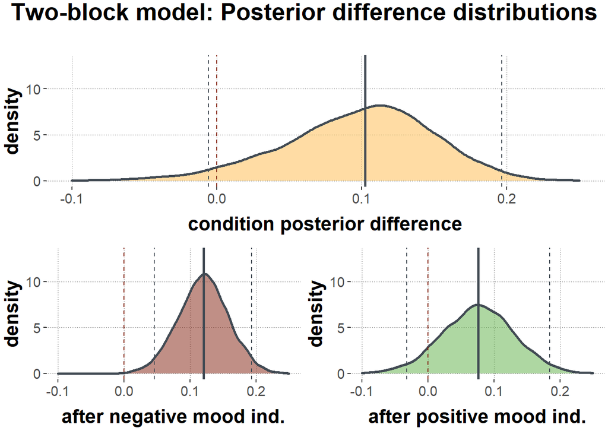

Indeed, the difference between congruent and incongruent condition, i.e. the AAB, is not significant after positive mood induction but only after negative mood induction.

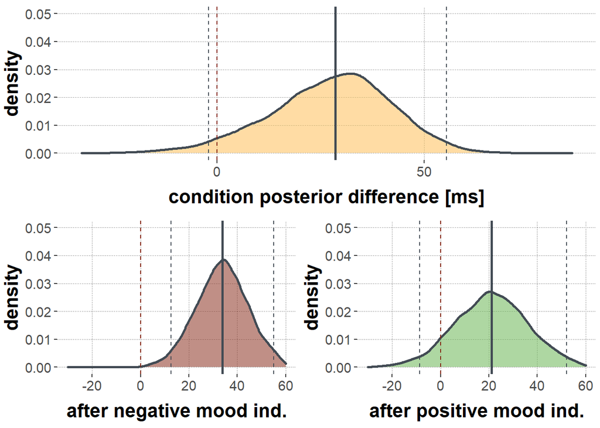

```
## # A tibble: 3 x 4
##   posteriors                               median CrI_lower CrI_upper
##   <chr>                                     <dbl>     <dbl>     <dbl>
## 1 condition difference                       28.6     -2.03      55.5
## 2 difference after negative mood induction   33.9     12.7       55.1
## 3 difference after positive mood induction   21.2     -8.70      52.2
```

```
## [1] "condition difference regardless of mood induction:"
```

```
## Summary of Posterior Distribution
##
## Parameter | Median |        95% CI |     pd |          ROPE | % in ROPE
## -----------------------------------------------------------------------
## posterior |   0.10 | [-0.01, 0.20] | 95.82% | [-0.10, 0.10] |    47.18%
```

```
## [1] "condition difference after negative mood induction:"
```

```
## Summary of Posterior Distribution
##
## Parameter | Median |       95% CI |     pd |          ROPE | % in ROPE
## ----------------------------------------------------------------------
## posterior |   0.12 | [0.05, 0.19] | 99.96% | [-0.10, 0.10] |    28.21%
```

```
## [1] "condition difference after positive mood induction:"
```

```
## Summary of Posterior Distribution
##
## Parameter | Median |        95% CI |     pd |          ROPE | % in ROPE
## -----------------------------------------------------------------------
## posterior |   0.08 | [-0.03, 0.18] | 91.67% | [-0.10, 0.10] |    67.70%
```

```
## [1] "Is there a difference between the AAB (i.e. difference in RTs between conditions) after positive compared to after negative MI?"
```

```
## [1] "positive AAB in negative AAB:"
```

```
## Summary of Posterior Distribution
##
## Parameter |        95% CI |         ROPE | % in ROPE
## ----------------------------------------------------
## posterior | [-0.03, 0.18] | [0.05, 0.19] |    72.64%
```

```
## [1] "negative AAB in positive AAB:"
```

```
## Summary of Posterior Distribution
##
## Parameter |       95% CI |          ROPE | % in ROPE
## ----------------------------------------------------
## posterior | [0.05, 0.19] | [-0.03, 0.18] |    97.88%
```

#### Difference distributions for the difference in reaction times between positive and negative mood induction:

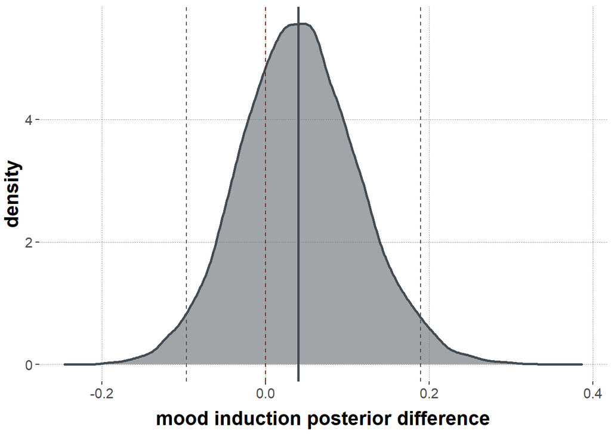

```
## [1] "mood induction difference regardless of condition:"
```

```
## Summary of Posterior Distribution
##
## Parameter | Median |        95% CI |     pd |          ROPE | % in ROPE
## -----------------------------------------------------------------------
## posterior |   0.04 | [-0.10, 0.19] | 71.62% | [-0.10, 0.10] |    81.11%
```

```r
# Hypothesis 1: After negative mood induction, reaction times are shorter in the incongruent than in the congruent condition.
hypothesis(fit_2block, "conditionincongruent < 0")
```

```
## Hypothesis Tests for class b:
##                 Hypothesis Estimate Est.Error CI.Lower CI.Upper Evid.Ratio
## 1 (conditionincongr... < 0     0.12      0.04     0.06     0.18          0
##   Post.Prob Star
## 1         0
## ---
## 'CI': 90%-CI for one-sided and 95%-CI for two-sided hypotheses.
## '*': For one-sided hypotheses, the posterior probability exceeds 95%;
## for two-sided hypotheses, the value tested against lies outside the 95%-CI.
## Posterior probabilities of point hypotheses assume equal prior probabilities.
```

```r
# --> reject hypothesis, test other way:
hypothesis(fit_2block, "conditionincongruent > 0")
```

```
## Hypothesis Tests for class b:
##                 Hypothesis Estimate Est.Error CI.Lower CI.Upper Evid.Ratio
## 1 (conditionincongr... > 0     0.12      0.04     0.06     0.18    2665.67
##   Post.Prob Star
## 1         1    *
## ---
## 'CI': 90%-CI for one-sided and 95%-CI for two-sided hypotheses.
## '*': For one-sided hypotheses, the posterior probability exceeds 95%;
## for two-sided hypotheses, the value tested against lies outside the 95%-CI.
## Posterior probabilities of point hypotheses assume equal prior probabilities.
```

```r
# Hypothesis 2: After positive mood induction, reaction times are longer in the incongruent than in the congruent condition.
hypothesis(fit_2block, "conditionincongruent + `conditionincongruent:mood_inductionpositive` > 0")
```

```
## Hypothesis Tests for class b:
##                 Hypothesis Estimate Est.Error CI.Lower CI.Upper Evid.Ratio
## 1 (conditionincongr... > 0     0.08      0.05    -0.01     0.17      11.01
##   Post.Prob Star
## 1      0.92
## ---
## 'CI': 90%-CI for one-sided and 95%-CI for two-sided hypotheses.
## '*': For one-sided hypotheses, the posterior probability exceeds 95%;
## for two-sided hypotheses, the value tested against lies outside the 95%-CI.
## Posterior probabilities of point hypotheses assume equal prior probabilities.
```

Given that when analyzing only the first two blocks, I don’t find an AAB in the positive mood induction condition, but only in the negative mood induction condition, the slight evidence from the main analysis in favour of the assumption that there might be a difference in AAB between the two mood induction conditions, has grown. But, of course, the sample size and effective sample size is also smaller than the sample sizes from the main analysis, so the results should be considered with caution.